# Severe Weather Events in the U.S. From 1950 to 2011

Jose A. Mora Soto

```r
# Libraries needed
library(data.table)
library(pander)
```

# 1 Synopsis

Severe weather events are one of the mayor disasters in the U.S. provoking several mortal victims and mayor economic losses. This report summarizes the information from the U.S. National Oceanic and Atmospheric Administration’s (NOAA) storm database showing information about the most fatal weather events in terms of mortality and economic consequences.

# 2 Data Processing

## 2.1 Data Source

The data used for this report is publicly offered by NOAA for any analysis and research purposes; the specific data for this report contains information about the severe weather events that occured in the U.S. from 1950 to November 2011, this data file was provided as a resource in the **Reproducibe Research** course from the Jonh Hopkins University at Coursera for the second course project, it can be downloaded from this [web link](https://d396qusza40orc.cloudfront.net/repdata%2Fdata%2FStormData.csv.bz2).

## 2.2 First Steps Processing the Data

For practicity the data file was downloaded and uncompresed using the operating system’s tools and renamed as *StormData.csv*.

The first step to conduct the analysis was to load the database into a data frame as follows:

```r
# The data will be retrieved into the "stormdata" data frame, since the data
# file is big, we check if it has already loaded.
if (!exists("stormdata")) {
  stormdata <- read.csv("StormData.csv")
}
```

Once the data was loaded in the **stormdata** dataframe, some data preparation was done by creating some data structures to manipulate the data to create the report. The most relevant data structures defined were the following:

- **stormdata_dt**: A data table structure (it needs the **data.table** package) to store all the data from the original file and have extra funcitions to clean and prepare the data.
- **harmful_events**: A data table structure to store the data needed to answer Question 1 of the project project.
- **economic_impact**: A data frame structure to store the data needed to answer Question 2 of the course project.

## 2.3 Data Processing for Question 1

In order to answer Question 1 **Across the United States, which types of events (as indicated in the **EVTYPE** variable) are most harmful with respect to population health?** it has been considered that the most harmful situation is dead, so the number of fatalities per severe weather event were used as indicator. The data was retrieved and stored in the **harmful_events** data table as follows:

```r
# Data preparatrion
stormdata_dt <- data.table(stormdata)
stormdata_dt$EVTYPE <- toupper(stormdata_dt$EVTYPE)
# Sum all FATALITIES per EVTYPE
harmful_events <- stormdata_dt[, sum(FATALITIES), by = EVTYPE]
harmful_events <- harmful_events[order(-V1),]
names(harmful_events) = c("EventType", "TotalFatalities")
harmful_events <- harmful_events[
  which(harmful_events$TotalFatalities > 0 &
          substr(harmful_events$EventType, 1, 7) != "SUMMARY")
  ]
```

## 2.4 Data Processing for Question 2

In order to ansquer Question 2 **Across the United States, which types of events have the greatest economic consequences?** the data was retrieved and stored in the **economic_impact** data frame; later the economic loss was calculated by losses in crops as well as in properties as it is shown in the code bellow.

```r
# Data preparation
exponent <- c('H' = 100, 'K' = 1000, 'M' = 1000000, 'B' = 1000000000)
if (!exists("economic_impact")) {
 # Creating the economic_impact dataframe
  economic_impact <- data.frame(
                                "EVTYPE" = stormdata_dt$EVTYPE,
                                "PROMDMG" = stormdata_dt$PROPDMG,
                                "PROPDMGEXP" = toupper(stormdata_dt$PROPDMGEXP),
                                "CROPDMG" = stormdata_dt$CROPDMG,
                                "CROPDMGEXP" = toupper(stormdata_dt$CROPDMGEXP)
                                )
  # Calculating the monetary impact of each damage
  economic_impact$PROPDMGCASH <- economic_impact$PROMDMG *
                              exponent[as.character(economic_impact$PROPDMGEXP)]
  economic_impact$CROPDMGCASH <- economic_impact$CROPDMG *
                              exponent[as.character(economic_impact$CROPDMGEXP)]

# Top 10 most costly events by properties and crops
# Economic Loss in properties
economic_impact_prop <- aggregate(
  economic_impact$PROPDMGCASH ~ economic_impact$EVTYPE,
  economic_impact,
  sum
)
names(economic_impact_prop) <- c("EVTYPE", "PROPDMGCASH")
economic_impact_prop <-
  economic_impact_prop[order(-economic_impact_prop$PROPDMGCASH),]

# Economic Loss in crops
economic_impact_crop <- aggregate(
  economic_impact$CROPDMGCASH ~ economic_impact$EVTYPE,
  economic_impact,
  sum
)
names(economic_impact_crop) <- c("EVTYPE", "CROPDMGCASH")
economic_impact_crop <-
  economic_impact_crop[order(-economic_impact_crop$CROPDMGCASH),]
}
```

# 3 Results

Once the data was processed it is possible to present some results about the impact of the severe weather events in the U.S.

## 3.1 Question 1 **Across the United States, which types of events (as indicated in the **EVTYPE** variable) are most harmful with respect to population health?**

Bellow in Table 1 a list of the top 10 most harmful severe weather events in the U.S. is presented, as can be seen **Tornados** are the events with the greater number of fatalities from 1950 to 2011.

```r
panderOptions("digits", 2)
set.caption("Table 1: Most Harmful Events in the U.S.
            (by number of fatalities)")
pander(head(harmful_events, 10))
```

Table 1: Most Harmful Events in the U.S. (by number of fatalities)

| EventType | TotalFatalities |
| --- | --- |
| TORNADO | 5633 |
| EXCESSIVE HEAT | 1903 |
| FLASH FLOOD | 978 |
| HEAT | 937 |
| LIGHTNING | 816 |
| TSTM WIND | 504 |
| FLOOD | 470 |
| RIP CURRENT | 368 |
| HIGH WIND | 248 |
| AVALANCHE | 224 |

Following a bar plot is presented to graphicaly depict the results from Table 1.

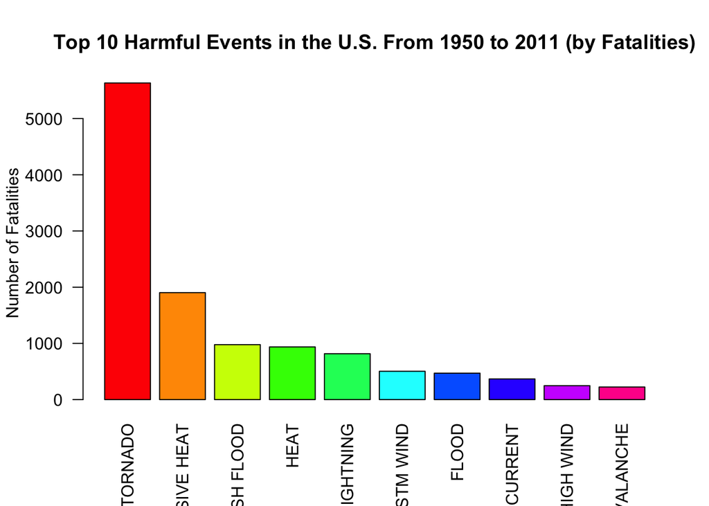

```r
par(las = 2) # Labels are perpendicular to the axis
barplot(head(harmful_events$TotalFatalities, 10),
  main = "Top 10 Harmful Events in the U.S. From 1950 to 2011 (by Fatalities)",
  names.arg = harmful_events$EventType[1:10],
  ylab = "Number of Fatalities",
  col = rainbow(10)
  )
```

**Figure 1: Most Harmful Events in the U.S. (by number of fatalities)**

## 3.2 Question 2: **Across the United States, which types of events have the greatest economic consequences?**

To answer this question the data was splited in two dimensions, one to analyze the economic loss in crops and another to analyze the economic loss in properties (as presented above in the the **Data Processing** section). Next in Figure 2 a pie chart showing the percentage of the total economic losses that were suffered in crops and propierties is presented.

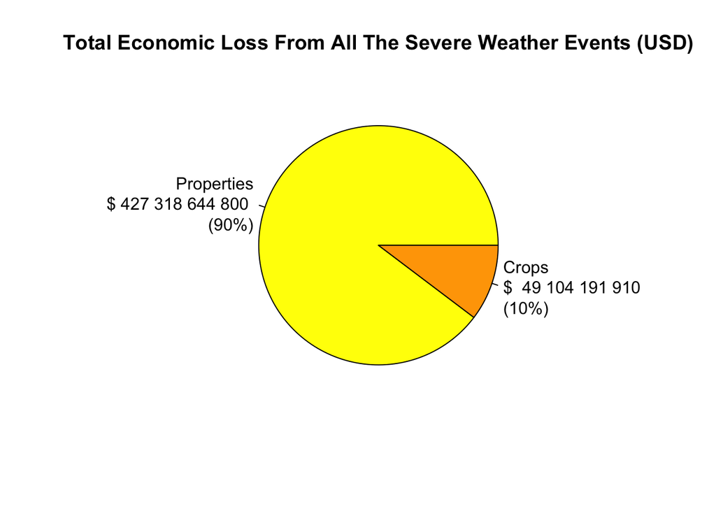

```r
slices = c(sum(economic_impact$PROPDMGCASH, na.rm = T),
           sum(economic_impact$CROPDMGCASH, na.rm = T))
lbls = c("Properties", "Crops")
pct = round(slices/sum(slices)*100)
lbls = paste(lbls,
             format(slices,
                    decimal.mark = ".",
                    big.mark = " ",
                    small.mark = ",",
                    small.interval = 3),
             sep = "\n$ ") # add the money
lbls = paste(lbls, "\n(")
lbls = paste(lbls, pct, sep = "")
lbls = paste(lbls, "%)", sep = "")
pie(
  slices,
  lbls,
  main = "Total Economic Loss From All The Severe Weather Events (USD)",
  col = c("Yellow", "Orange")
  )
```

**Figure 2: Total Economic Loss From All The Severe Weather Events (USD)**

Finally in Figure 3 a bar chart is presented in Figure 3 to present the top 10 most costly severe events in terms of losses in properties.

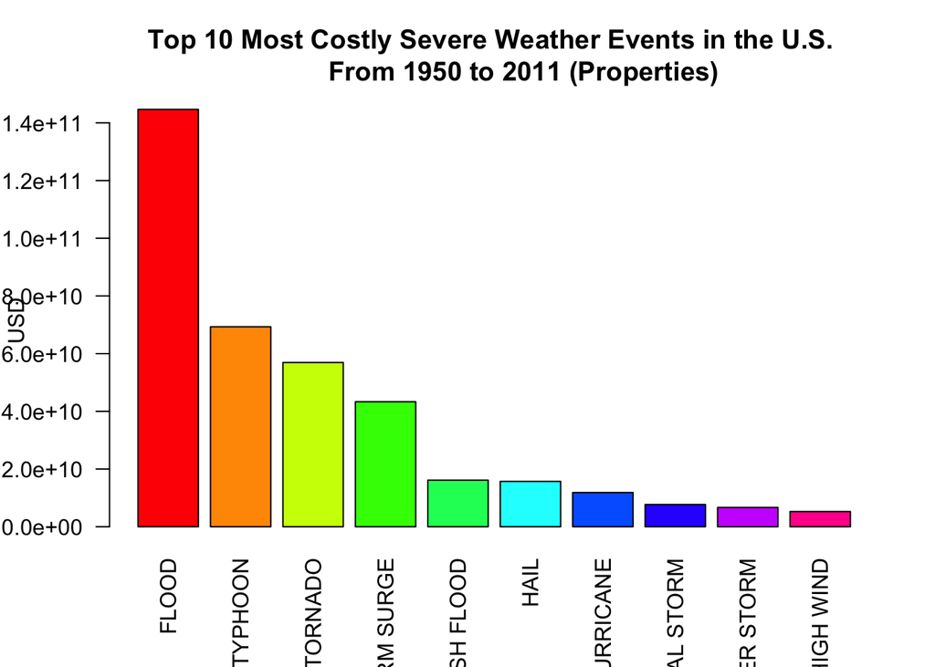

```r
par(las = 2)
barplot(head(economic_impact_prop$PROPDMGCASH, 10),
        main = "Top 10 Most Costly Severe Weather Events in the U.S.
        From 1950 to 2011 (Properties)",
        names.arg = economic_impact_prop$EVTYPE[1:10],
        ylab = "USD",
        col = rainbow(10)
)
```

**Figure 3: Top 10 Most Costly Severe Weather Events in the U.S. From 1950 to 2011 (Properties)**

# 4 Full Code to Reproduce this Analysis

If you want to see and play yourself with the code I made to create this report, you can download it at my [GitHub code repository for this project](https://github.com/jarturomora/datasciencecoursera/tree/master/course5/courseproject2).

In case you want to contact me, [feel free to contact me](https://about.me/jarturomora).